# day5

```r
# i am using jupyter notebooks, not RStudio. Jupyter notebooks dont support interactive graphs
# so I dont know whether plotly will work - you might need to update jasonlite and run the following commant
# but try running the command below first and see whether you get any errors when intalling the libraries
install.packages("jsonlite", repos = 'https://cran.r-project.org')
```

```r
#install.packages('readr')
#install.packages('ggplot2')
#install.packages('mlbench')
#install.packages('corrplot')
#install.packages('Amelia')
#install.packages('caret')
#install.packages('plotly')
#install.packages('caTools')
#install.packages('reshape2')
#install.packages('dplyr')
```

[output not shown]

```r
library(MASS)
library(readr)
library(ggplot2)
library(corrplot)
library(mlbench)
library(Amelia)
#library(plotly)
library(reshape2)
#library(caret)
library(caTools)
library(dplyr)
```

### the amelia package is nice to check and visualise whether there are any missing values in your dataset

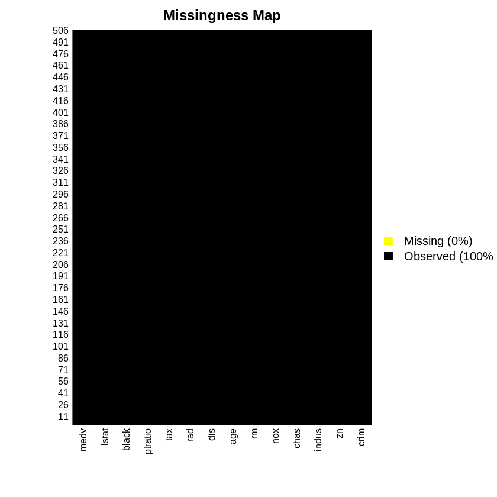

```r
BostonHousing = Boston
missmap(BostonHousing,col=c('yellow','black'),legend=TRUE)
```

### we see that the dataset is complete and doesnt contain any missing values

### corrplot is a nice library to build a beautiful correlation plot to show the correlation between variables

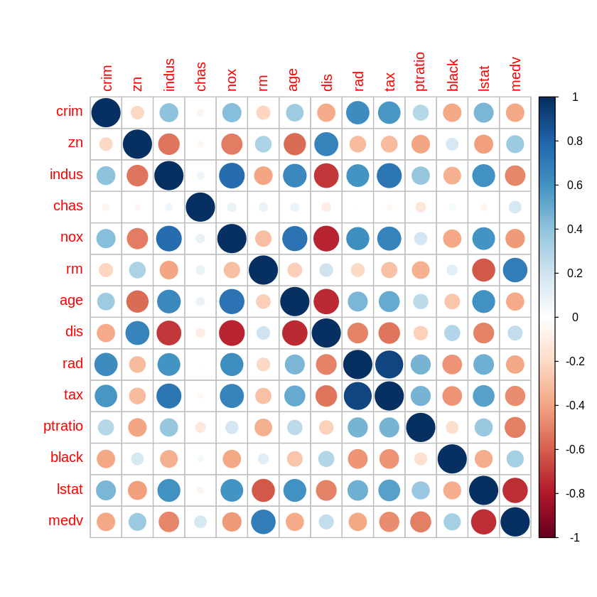

```r
corrplot(cor(BostonHousing))
```

### we can see that medv decreases with increase in crim (medium), indus (High),nox(low),age(low),rad(low),tax(low),ptratio(high), lstat (High) and increases with increase in zn(low),rm(High)

# faster way to train and test your models in R

### NOTE: since you were given only half of the data during the session you do not need to do the following. You should use your data as training data and the new data as test data. However, if you have followed the steps above and loaded the dataset from the MASS library, go on and execude the code below:

## Train and Test data

### lets split the data into train and test data (that's what caTools libarry is for)

```r
#set a seed
set.seed(123)

#Split the data , `split()` assigns a booleans to a new column based on the SplitRatio specified.

split = sample.split(BostonHousing,SplitRatio =0.75)


train = subset(BostonHousing,split==TRUE)
test = subset(BostonHousing,split==FALSE)

# now we are using 75% of the data for training or model and 25% for testing our model
```

### let's build our model using the variables that have a medium to high correlation with medv

- crim
- indus
- nox
- rm
- tax
- ptratio
- lstat

```r
model_1 = lm(medv ~ crim + indus + nox + rm + tax + ptratio + lstat, data=train)
```

```r
summary(model_1)
```

```
Call:
lm(formula = medv ~ crim + indus + nox + rm + tax + ptratio +
    lstat, data = train)

Residuals:
     Min       1Q   Median       3Q      Max
-14.1639  -2.7877  -0.8688   1.7620  30.3921

Coefficients:
             Estimate Std. Error t value Pr(>|t|)
(Intercept) 15.149661   4.888013   3.099  0.00209 **
crim        -0.065477   0.035836  -1.827  0.06853 .
indus        0.060019   0.067027   0.895  0.37116
nox         -3.615661   3.787512  -0.955  0.34042
rm           5.036017   0.482066  10.447  < 2e-16 ***
tax         -0.002395   0.002629  -0.911  0.36305
ptratio     -0.865093   0.145517  -5.945 6.63e-09 ***
lstat       -0.471667   0.059574  -7.917 3.16e-14 ***
---
Signif. codes:  0 ‘***’ 0.001 ‘**’ 0.01 ‘*’ 0.05 ‘.’ 0.1 ‘ ’ 1

Residual standard error: 4.957 on 354 degrees of freedom
Multiple R-squared:  0.7112,	Adjusted R-squared:  0.7055
F-statistic: 124.6 on 7 and 354 DF,  p-value: < 2.2e-16
```

```r
# we can see that crim, indus, nox and tax are not significant,
# lets build another model with less variables
model_2 = lm(medv ~  rm + ptratio + lstat, data=train)
summary(model_2)
```

```
Call:
lm(formula = medv ~ rm + ptratio + lstat, data = train)

Residuals:
    Min      1Q  Median      3Q     Max
-14.752  -2.865  -0.690   1.974  29.165

Coefficients:
            Estimate Std. Error t value Pr(>|t|)
(Intercept) 16.27791    4.35365   3.739 0.000215 ***
rm           4.76309    0.47638   9.998  < 2e-16 ***
ptratio     -0.91722    0.13080  -7.012 1.18e-11 ***
lstat       -0.55163    0.04826 -11.430  < 2e-16 ***
---
Signif. codes:  0 ‘***’ 0.001 ‘**’ 0.01 ‘*’ 0.05 ‘.’ 0.1 ‘ ’ 1

Residual standard error: 4.992 on 358 degrees of freedom
Multiple R-squared:  0.7038,	Adjusted R-squared:  0.7013
F-statistic: 283.5 on 3 and 358 DF,  p-value: < 2.2e-16
```

### we can see that R squared almost has not changed so we made the right decision to exclude the useless variables

## visualising the model

### let's plot the residuals

```r
res_1 = residuals(model_1)
# convert residuals into a dataframe
res_1 = as.data.frame(res_1)
```

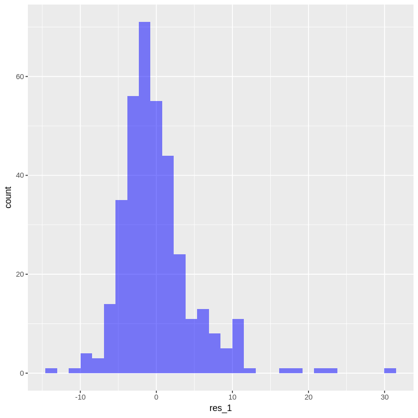

```r
ggplot(res_1,aes(res_1)) +  geom_histogram(fill='blue',alpha=0.5)
```

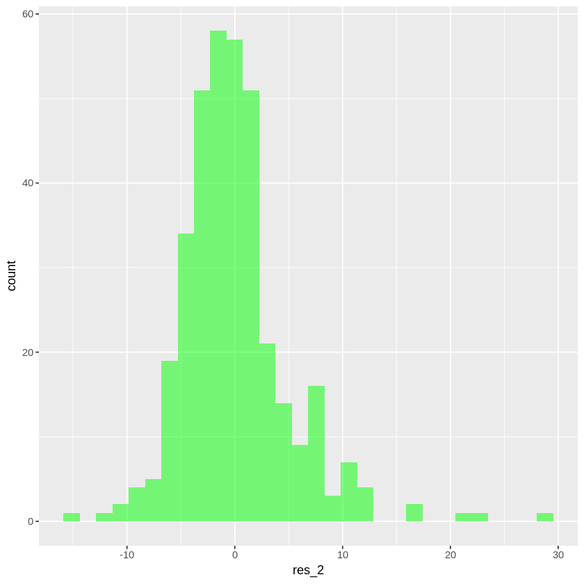

```r
res_2 = residuals(model_2)
# convert residuals into a dataframe
res_2 = as.data.frame(res_2)
ggplot(res_2,aes(res_2)) +  geom_histogram(fill='green',alpha=0.5)
```

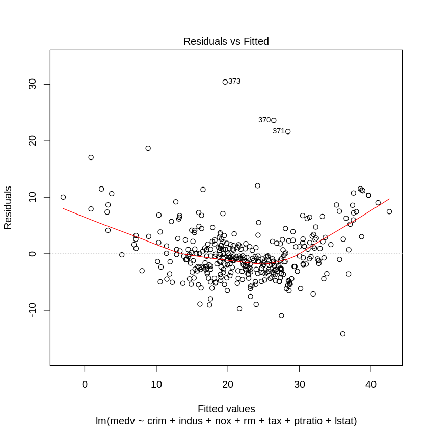

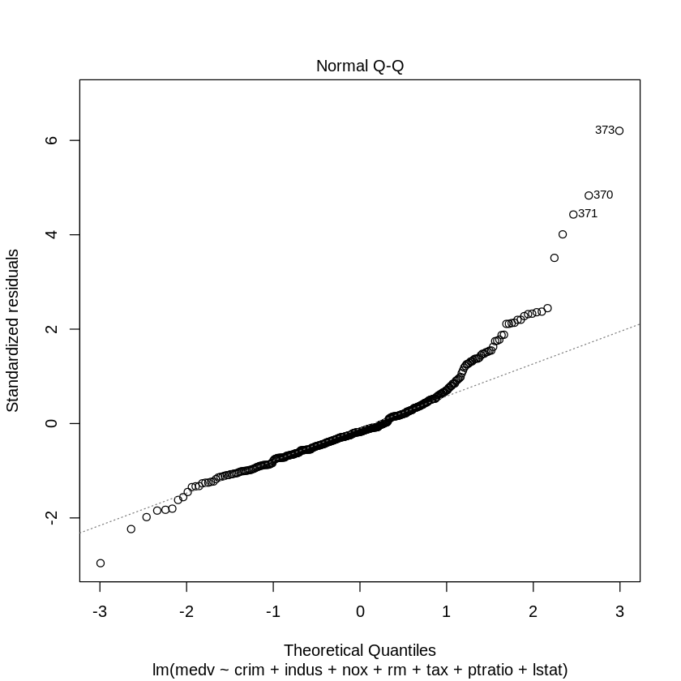

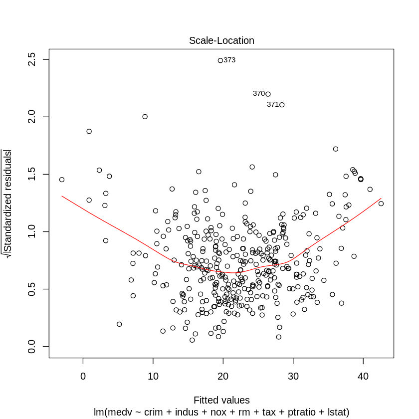

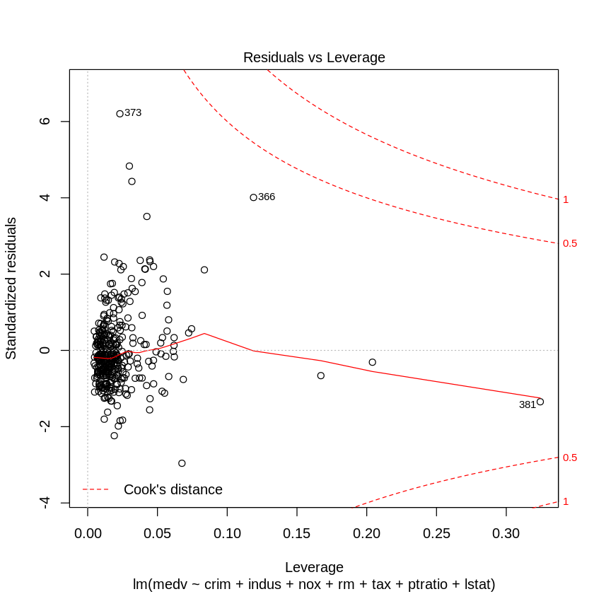

```r
plot(model_1)
```

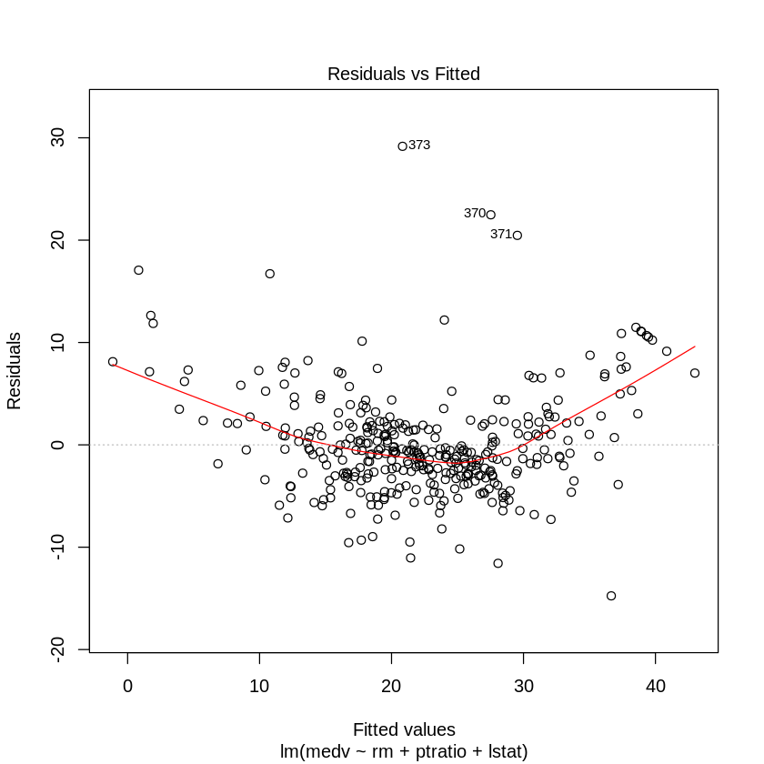

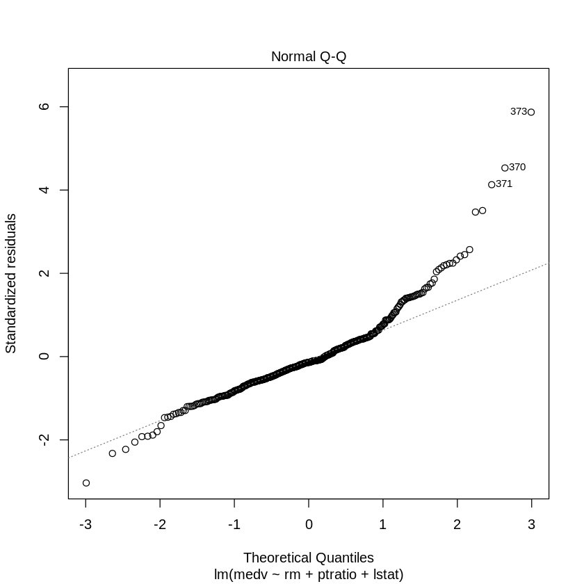

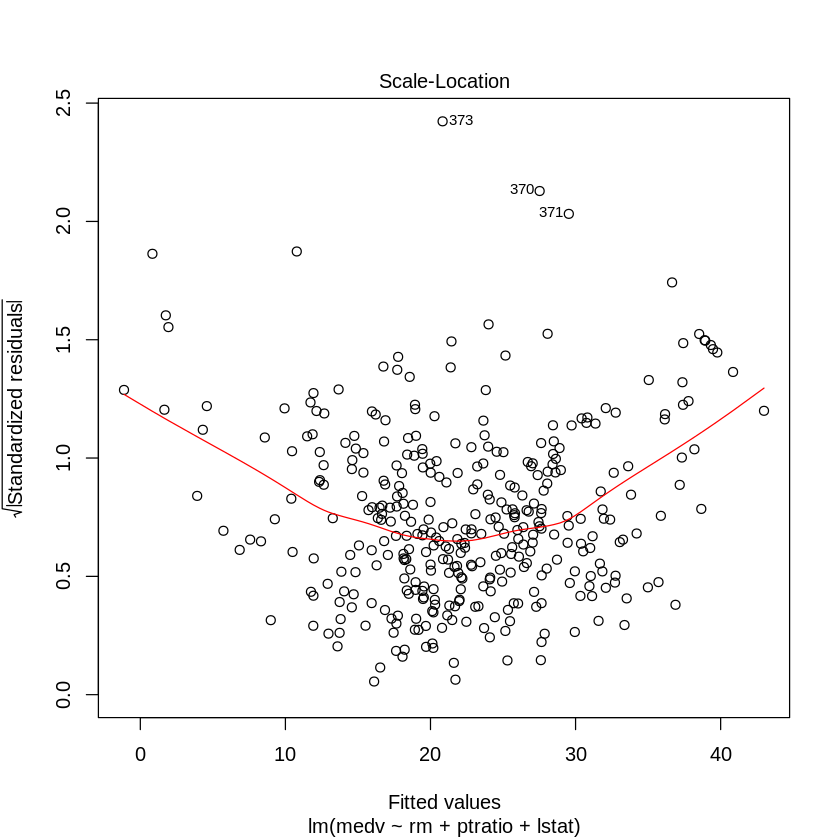

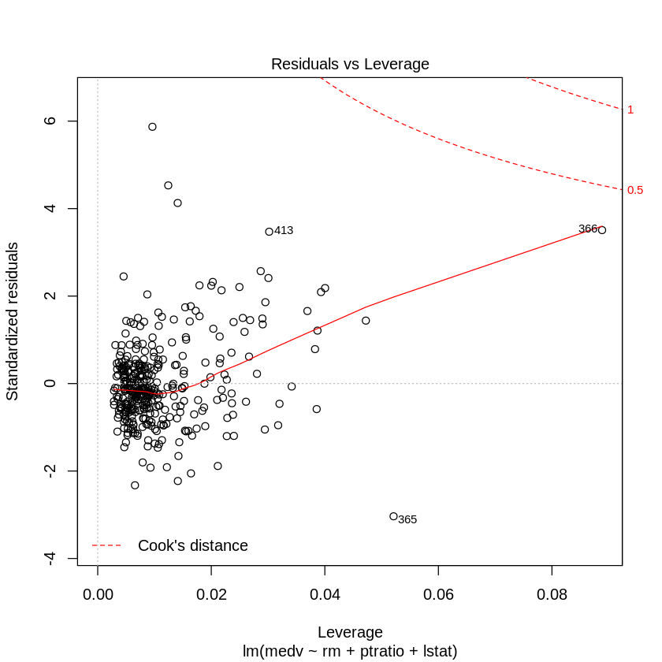

```r
plot(model_2)
```

### just for fun lets create a bad model to see the differences compared to the good models 1 and 2

```
Call:
lm(formula = medv ~ chas + dis, data = train)

Residuals:
    Min      1Q  Median      3Q     Max
-13.953  -5.593  -1.423   2.577  30.654

Coefficients:
            Estimate Std. Error t value Pr(>|t|)
(Intercept)  17.0714     0.9652  17.686  < 2e-16 ***
chas          7.2250     1.7137   4.216 3.15e-05 ***
dis           1.2631     0.2179   5.797 1.48e-08 ***
---
Signif. codes:  0 ‘***’ 0.001 ‘**’ 0.01 ‘*’ 0.05 ‘.’ 0.1 ‘ ’ 1

Residual standard error: 8.629 on 359 degrees of freedom
Multiple R-squared:  0.1126,	Adjusted R-squared:  0.1076
F-statistic: 22.77 on 2 and 359 DF,  p-value: 4.894e-10
```

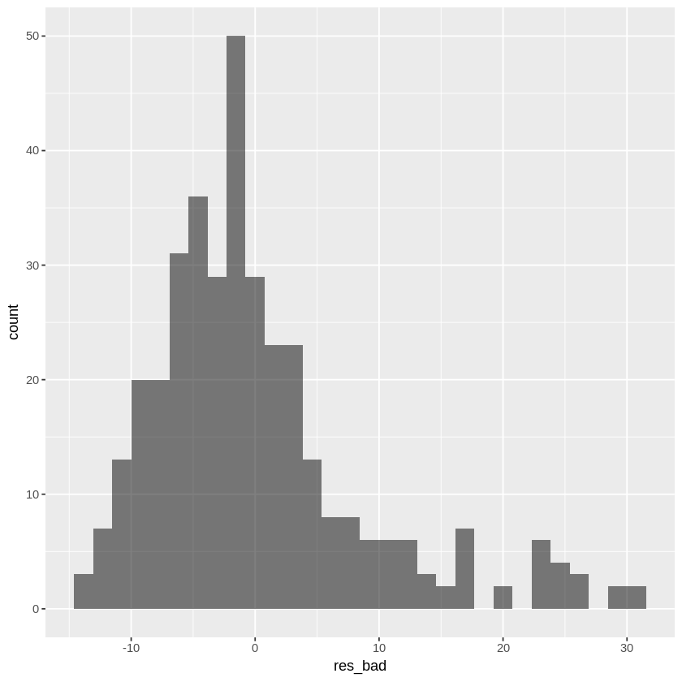

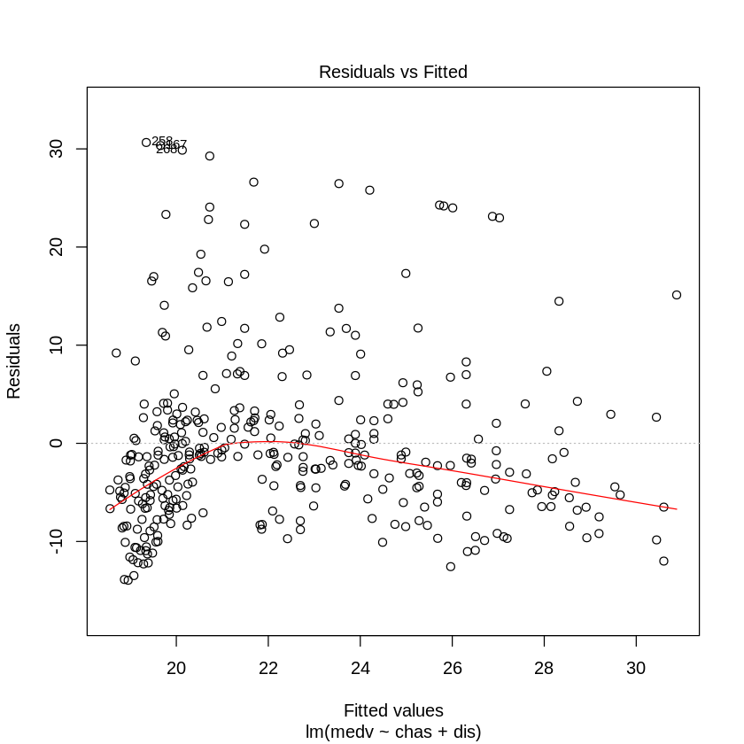

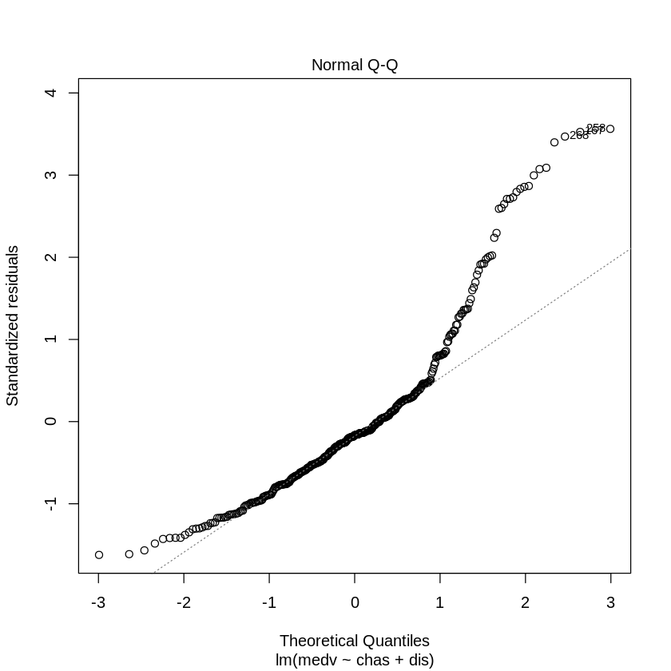

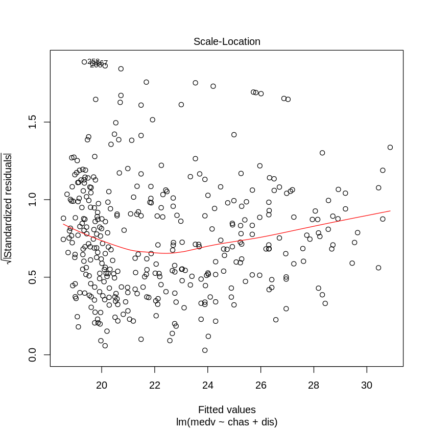

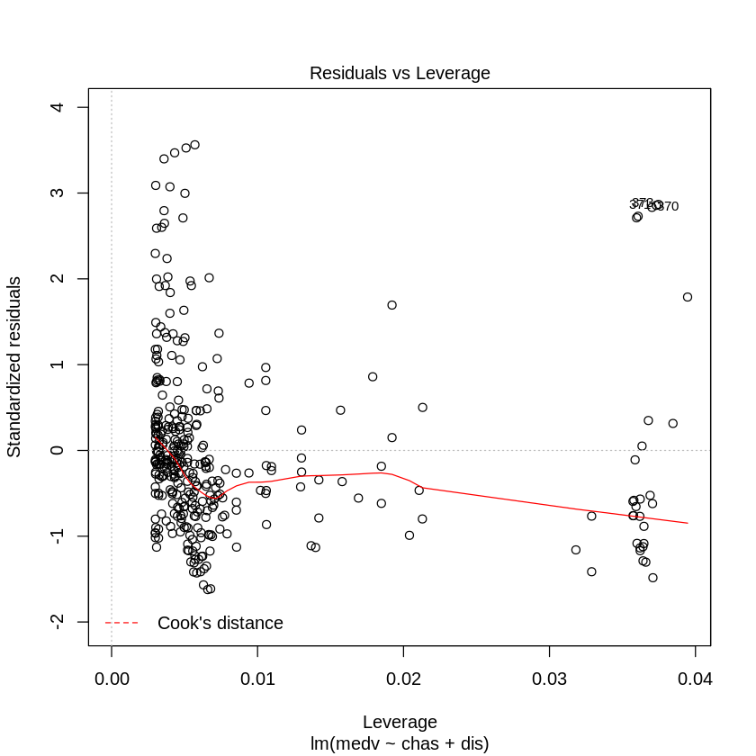

```r
bad_model = lm(medv ~ chas + dis, data=train)
summary(bad_model)
res_bad = residuals(bad_model)
# convert residuals into a dataframe
res_bad = as.data.frame(res_bad)
ggplot(res_bad,aes(res_bad)) +  geom_histogram(fill='black',alpha=0.5)
plot(bad_model)
```

## Prediction!

### let's test our model by prediction medv on our testing dataset

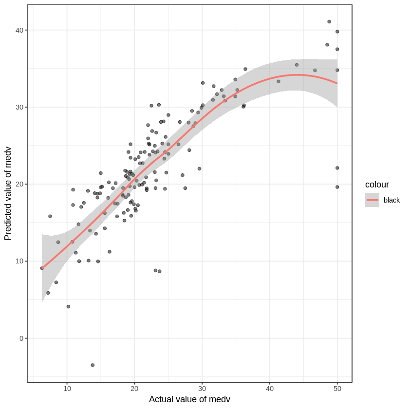

```r
test$predicted.medv = predict(model_2,test)
library(dplyr) #the piping

pl_model2 <-test %>%
  ggplot(aes(medv,predicted.medv)) +
  geom_point(alpha=0.5) +
  stat_smooth(aes(colour='black')) +
  xlab('Actual value of medv') +
  ylab('Predicted value of medv')+
  theme_bw()

#ggplotly(pl1)  I am using jupyter so interactive graphs are not supported
plot(pl_model2)
```

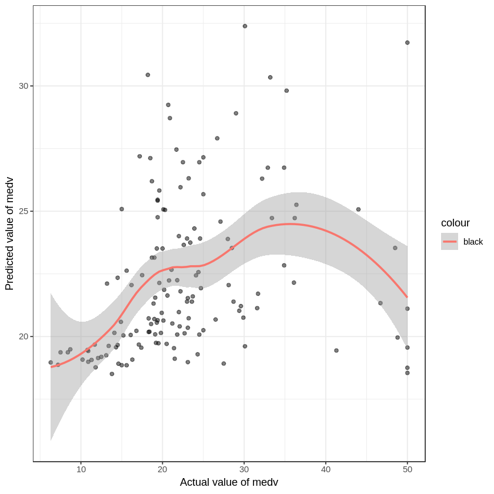

```r
#comparison to bad model

test$predicted.medv = predict(bad_model,test)
library(dplyr) #the piping

pl_bad <-test %>%
  ggplot(aes(medv,predicted.medv)) +
  geom_point(alpha=0.5) +
  stat_smooth(aes(colour='black')) +
  xlab('Actual value of medv') +
  ylab('Predicted value of medv')+
  theme_bw()

#ggplotly(pl1)
plot(pl_bad)
```

## Interaction terms

### how to choose interaction terms. go back to the correlation plot at the beginning of the notebook. we can see that rm and lstat are highly correlated. since both of these variables are included in our model, let's make them interactive

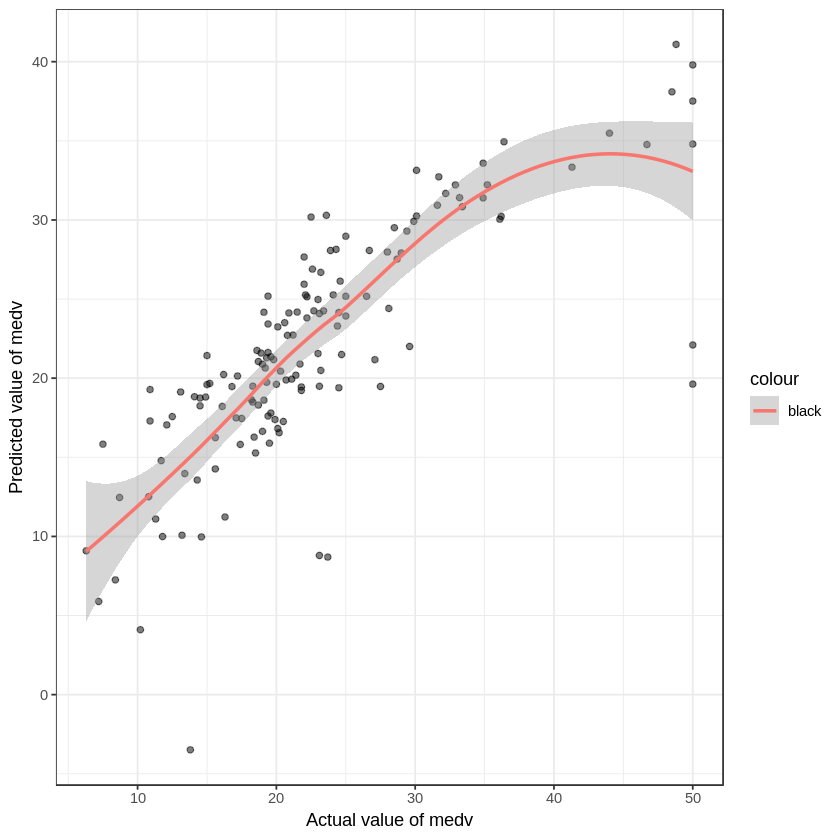

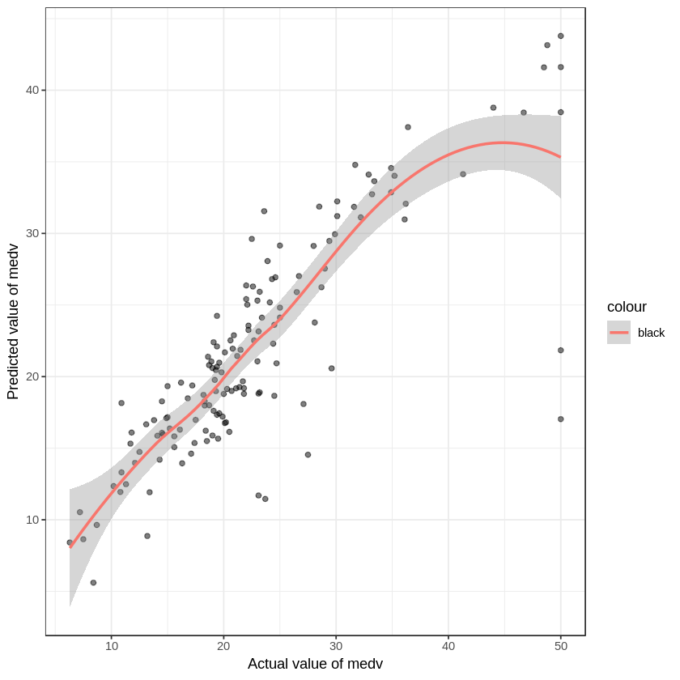

```r
model_interact = lm(medv ~  rm * lstat +  ptratio, data=train)
test$predicted.medv = predict(model_interact,test)


pl_interact <-test %>%
  ggplot(aes(medv,predicted.medv)) +
  geom_point(alpha=0.5) +
  stat_smooth(aes(colour='black')) +
  xlab('Actual value of medv') +
  ylab('Predicted value of medv')+
  theme_bw()

par(mfrow=c(1,2))
#ggplotly(pl1)  I am using jupyter so interactive graphs are not supported
plot(pl_model2)
plot(pl_interact)
```

```r
### we can actually see that in the second model the predictions are slightly better. lets compare the two models
```

```r
summary(model_2)
```

```
Call:
lm(formula = medv ~ rm + ptratio + lstat, data = train)

Residuals:
    Min      1Q  Median      3Q     Max
-14.752  -2.865  -0.690   1.974  29.165

Coefficients:
            Estimate Std. Error t value Pr(>|t|)
(Intercept) 16.27791    4.35365   3.739 0.000215 ***
rm           4.76309    0.47638   9.998  < 2e-16 ***
ptratio     -0.91722    0.13080  -7.012 1.18e-11 ***
lstat       -0.55163    0.04826 -11.430  < 2e-16 ***
---
Signif. codes:  0 ‘***’ 0.001 ‘**’ 0.01 ‘*’ 0.05 ‘.’ 0.1 ‘ ’ 1

Residual standard error: 4.992 on 358 degrees of freedom
Multiple R-squared:  0.7038,	Adjusted R-squared:  0.7013
F-statistic: 283.5 on 3 and 358 DF,  p-value: < 2.2e-16
```

```r
summary(model_interact)
```

```
Call:
lm(formula = medv ~ rm * lstat + ptratio, data = train)

Residuals:
     Min       1Q   Median       3Q      Max
-20.0794  -2.4286  -0.3964   2.0432  29.4169

Coefficients:
             Estimate Std. Error t value Pr(>|t|)
(Intercept) -13.56158    4.59196  -2.953  0.00335 **
rm            8.96139    0.55461  16.158  < 2e-16 ***
lstat         1.98915    0.22982   8.655  < 2e-16 ***
ptratio      -0.66038    0.11487  -5.749 1.93e-08 ***
rm:lstat     -0.43756    0.03893 -11.240  < 2e-16 ***
---
Signif. codes:  0 ‘***’ 0.001 ‘**’ 0.01 ‘*’ 0.05 ‘.’ 0.1 ‘ ’ 1

Residual standard error: 4.296 on 357 degrees of freedom
Multiple R-squared:  0.7812,	Adjusted R-squared:  0.7788
F-statistic: 318.7 on 4 and 357 DF,  p-value: < 2.2e-16
```

```r
anova(model_interact, model_2)
#we can see that the model with the interaction is better since the RR went down
```

| Res.Df | RSS | Df | Sum of Sq | F | Pr(>F) |
| --- | --- | --- | --- | --- | --- |
| 357 | 6589.669 | NA | NA | NA | NA |
| 358 | 8921.834 | -1 | -2332.165 | 126.3467 | 2.656968e-25 |